# Risk Factor Analysis

## Outcome Variable

**Outcome Variable:** pers_wast

## Predictor Variables

**Intervention Variable:** hdlvry

**Adjustment Set:**

- arm
- sex
- W_mage
- meducyrs
- feducyrs
- hhwealth_quart
- single
- W_nrooms
- brthmon
- W_parity
- impsan
- delta_W_mage
- delta_meducyrs
- delta_feducyrs
- delta_hhwealth_quart
- delta_single
- delta_W_nrooms
- delta_brthmon
- delta_W_parity
- delta_impsan

## Stratifying Variables

The analysis was stratified on these variable(s):

- agecat
- studyid
- country

## Data Summary

| agecat | studyid | country | hdlvry | pers_wast | n_cell | n |
| --- | --- | --- | --- | --- | --- | --- |
| 0-24 months | CMC-V-BCS-2002 | INDIA | 0 | 0 | 339 | 370 |
| 0-24 months | CMC-V-BCS-2002 | INDIA | 0 | 1 | 23 | 370 |
| 0-24 months | CMC-V-BCS-2002 | INDIA | 1 | 0 | 8 | 370 |
| 0-24 months | CMC-V-BCS-2002 | INDIA | 1 | 1 | 0 | 370 |
| 0-24 months | COHORTS | INDIA | 0 | 0 | 2249 | 3931 |
| 0-24 months | COHORTS | INDIA | 0 | 1 | 197 | 3931 |
| 0-24 months | COHORTS | INDIA | 1 | 0 | 1292 | 3931 |
| 0-24 months | COHORTS | INDIA | 1 | 1 | 193 | 3931 |
| 0-24 months | EE | PAKISTAN | 0 | 0 | 232 | 375 |
| 0-24 months | EE | PAKISTAN | 0 | 1 | 20 | 375 |
| 0-24 months | EE | PAKISTAN | 1 | 0 | 111 | 375 |
| 0-24 months | EE | PAKISTAN | 1 | 1 | 12 | 375 |
| 0-24 months | GMS-Nepal | NEPAL | 0 | 0 | 121 | 556 |
| 0-24 months | GMS-Nepal | NEPAL | 0 | 1 | 18 | 556 |
| 0-24 months | GMS-Nepal | NEPAL | 1 | 0 | 359 | 556 |
| 0-24 months | GMS-Nepal | NEPAL | 1 | 1 | 58 | 556 |
| 0-24 months | IRC | INDIA | 0 | 0 | 354 | 410 |
| 0-24 months | IRC | INDIA | 0 | 1 | 48 | 410 |
| 0-24 months | IRC | INDIA | 1 | 0 | 8 | 410 |
| 0-24 months | IRC | INDIA | 1 | 1 | 0 | 410 |
| 0-24 months | JiVitA-3 | BANGLADESH | 0 | 0 | 36 | 323 |
| 0-24 months | JiVitA-3 | BANGLADESH | 0 | 1 | 1 | 323 |
| 0-24 months | JiVitA-3 | BANGLADESH | 1 | 0 | 273 | 323 |
| 0-24 months | JiVitA-3 | BANGLADESH | 1 | 1 | 13 | 323 |
| 0-24 months | JiVitA-4 | BANGLADESH | 0 | 0 | 1077 | 4426 |
| 0-24 months | JiVitA-4 | BANGLADESH | 0 | 1 | 72 | 4426 |
| 0-24 months | JiVitA-4 | BANGLADESH | 1 | 0 | 2998 | 4426 |
| 0-24 months | JiVitA-4 | BANGLADESH | 1 | 1 | 279 | 4426 |
| 0-24 months | NIH-Crypto | BANGLADESH | 0 | 0 | 551 | 730 |
| 0-24 months | NIH-Crypto | BANGLADESH | 0 | 1 | 16 | 730 |

[output cut: 94 more lines]

The following strata were considered:

- agecat: 0-24 months, studyid: CMC-V-BCS-2002, country: INDIA
- agecat: 0-24 months, studyid: COHORTS, country: INDIA
- agecat: 0-24 months, studyid: EE, country: PAKISTAN
- agecat: 0-24 months, studyid: GMS-Nepal, country: NEPAL
- agecat: 0-24 months, studyid: IRC, country: INDIA
- agecat: 0-24 months, studyid: JiVitA-3, country: BANGLADESH
- agecat: 0-24 months, studyid: JiVitA-4, country: BANGLADESH
- agecat: 0-24 months, studyid: NIH-Crypto, country: BANGLADESH
- agecat: 0-24 months, studyid: PROVIDE, country: BANGLADESH
- agecat: 0-24 months, studyid: SAS-CompFeed, country: INDIA
- agecat: 0-24 months, studyid: SAS-FoodSuppl, country: INDIA
- agecat: 0-24 months, studyid: TanzaniaChild2, country: TANZANIA, UNITED REPUBLIC OF
- agecat: 0-6 months, studyid: CMC-V-BCS-2002, country: INDIA
- agecat: 0-6 months, studyid: EE, country: PAKISTAN
- agecat: 0-6 months, studyid: GMS-Nepal, country: NEPAL
- agecat: 0-6 months, studyid: IRC, country: INDIA
- agecat: 0-6 months, studyid: NIH-Crypto, country: BANGLADESH
- agecat: 0-6 months, studyid: PROVIDE, country: BANGLADESH
- agecat: 0-6 months, studyid: TanzaniaChild2, country: TANZANIA, UNITED REPUBLIC OF
- agecat: 6-24 months, studyid: CMC-V-BCS-2002, country: INDIA
- agecat: 6-24 months, studyid: COHORTS, country: INDIA
- agecat: 6-24 months, studyid: EE, country: PAKISTAN
- agecat: 6-24 months, studyid: GMS-Nepal, country: NEPAL
- agecat: 6-24 months, studyid: IRC, country: INDIA
- agecat: 6-24 months, studyid: JiVitA-3, country: BANGLADESH
- agecat: 6-24 months, studyid: JiVitA-4, country: BANGLADESH
- agecat: 6-24 months, studyid: NIH-Crypto, country: BANGLADESH
- agecat: 6-24 months, studyid: PROVIDE, country: BANGLADESH
- agecat: 6-24 months, studyid: SAS-CompFeed, country: INDIA
- agecat: 6-24 months, studyid: SAS-FoodSuppl, country: INDIA
- agecat: 6-24 months, studyid: TanzaniaChild2, country: TANZANIA, UNITED REPUBLIC OF

### Dropped Strata

Some strata were dropped due to rare outcomes:

- agecat: 0-24 months, studyid: CMC-V-BCS-2002, country: INDIA
- agecat: 0-24 months, studyid: IRC, country: INDIA
- agecat: 0-24 months, studyid: JiVitA-3, country: BANGLADESH
- agecat: 0-24 months, studyid: TanzaniaChild2, country: TANZANIA, UNITED REPUBLIC OF
- agecat: 0-6 months, studyid: CMC-V-BCS-2002, country: INDIA
- agecat: 0-6 months, studyid: IRC, country: INDIA
- agecat: 0-6 months, studyid: NIH-Crypto, country: BANGLADESH
- agecat: 0-6 months, studyid: PROVIDE, country: BANGLADESH
- agecat: 0-6 months, studyid: TanzaniaChild2, country: TANZANIA, UNITED REPUBLIC OF
- agecat: 6-24 months, studyid: CMC-V-BCS-2002, country: INDIA
- agecat: 6-24 months, studyid: IRC, country: INDIA
- agecat: 6-24 months, studyid: JiVitA-3, country: BANGLADESH
- agecat: 6-24 months, studyid: TanzaniaChild2, country: TANZANIA, UNITED REPUBLIC OF

## Methods Detail

We’re interested in the causal parameters $E[Y_a]$ for all values of $a \in \mathcal{A}$. These parameters represent the mean outcome if, possibly contrary to fact, we intervened to set all units to have $A=a$. Under the randomization and positivity assumptions, these are identified by the statistical parameters $\psi_a=E_W[E_{Y|A,W}(Y|A=a,W)]$. In addition, we’re interested in the mean of $Y$, $E[Y]$ under no intervention (the observed mean). We will estimate these parameters by using SuperLearner to fit the relevant likelihood factors – $E_{Y|A,W}(Y|A=a,W)$ and $p(A=a|W)$, and then updating our likelihood fit using a joint TMLE.

For unadjusted analyses ($W=\{\}$), initial likelihoods were estimated using Lrnr_glm to estimate the simple $E(Y|A)$ and Lrnr_mean to estimate $p(A)$. For adjusted analyses, a small library containing Lrnr_glmnet, Lrnr_xgboost, and Lrnr_mean was used.

Having estimated these parameters, we will then use the delta method to estimate relative risks and attributable risks relative to a prespecified baseline level of $A$.

# Results Detail

## Results Plots

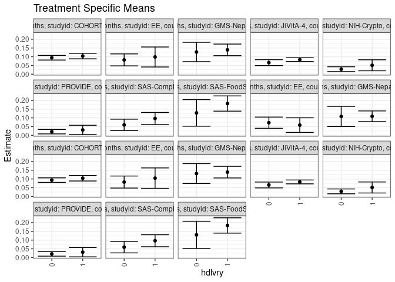

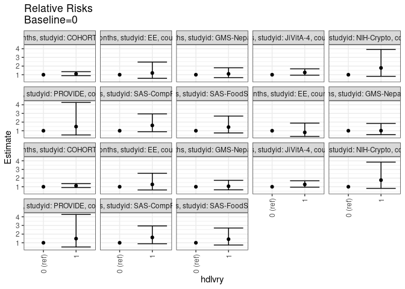

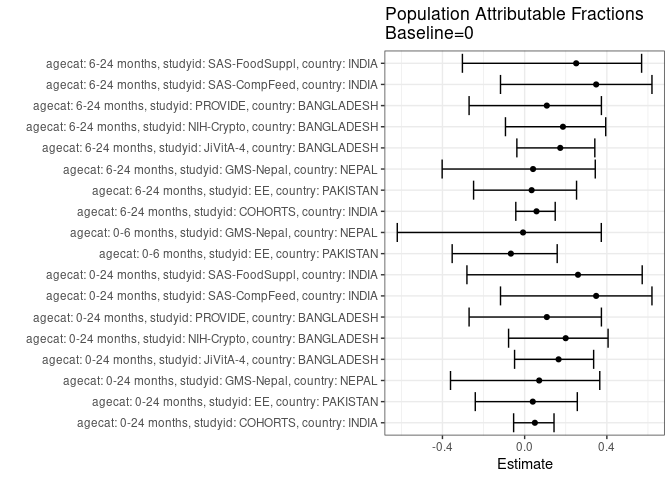

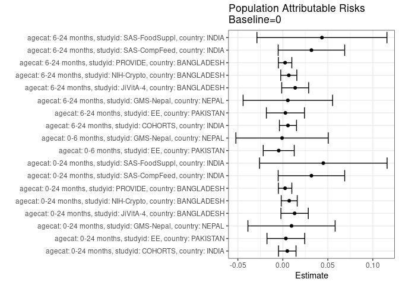

## Results Table

### Parameter: TSM

| agecat | studyid | country | intervention_level | baseline_level | estimate | ci_lower | ci_upper |
| --- | --- | --- | --- | --- | --- | --- | --- |
| 0-24 months | COHORTS | INDIA | 0 | NA | 0.0942824 | 0.0811162 | 0.1074486 |
| 0-24 months | COHORTS | INDIA | 1 | NA | 0.1038267 | 0.0879396 | 0.1197138 |
| 0-24 months | EE | PAKISTAN | 0 | NA | 0.0819602 | 0.0477025 | 0.1162179 |
| 0-24 months | EE | PAKISTAN | 1 | NA | 0.0985626 | 0.0413391 | 0.1557861 |
| 0-24 months | GMS-Nepal | NEPAL | 0 | NA | 0.1270118 | 0.0715897 | 0.1824340 |
| 0-24 months | GMS-Nepal | NEPAL | 1 | NA | 0.1392479 | 0.1059783 | 0.1725176 |
| 0-24 months | JiVitA-4 | BANGLADESH | 0 | NA | 0.0662047 | 0.0492367 | 0.0831728 |
| 0-24 months | JiVitA-4 | BANGLADESH | 1 | NA | 0.0833399 | 0.0723235 | 0.0943563 |
| 0-24 months | NIH-Crypto | BANGLADESH | 0 | NA | 0.0285053 | 0.0147577 | 0.0422529 |
| 0-24 months | NIH-Crypto | BANGLADESH | 1 | NA | 0.0508955 | 0.0193692 | 0.0824218 |
| 0-24 months | PROVIDE | BANGLADESH | 0 | NA | 0.0208768 | 0.0080633 | 0.0336904 |
| 0-24 months | PROVIDE | BANGLADESH | 1 | NA | 0.0308642 | 0.0042110 | 0.0575174 |
| 0-24 months | SAS-CompFeed | INDIA | 0 | NA | 0.0596026 | 0.0268592 | 0.0923461 |
| 0-24 months | SAS-CompFeed | INDIA | 1 | NA | 0.0963731 | 0.0619791 | 0.1307670 |
| 0-24 months | SAS-FoodSuppl | INDIA | 0 | NA | 0.1283419 | 0.0521272 | 0.2045566 |
| 0-24 months | SAS-FoodSuppl | INDIA | 1 | NA | 0.1821295 | 0.1384876 | 0.2257714 |
| 0-6 months | EE | PAKISTAN | 0 | NA | 0.0722892 | 0.0400799 | 0.1044984 |
| 0-6 months | EE | PAKISTAN | 1 | NA | 0.0583333 | 0.0163426 | 0.1003241 |
| 0-6 months | GMS-Nepal | NEPAL | 0 | NA | 0.1081849 | 0.0504638 | 0.1659061 |
| 0-6 months | GMS-Nepal | NEPAL | 1 | NA | 0.1090485 | 0.0784886 | 0.1396084 |
| 6-24 months | COHORTS | INDIA | 0 | NA | 0.0934899 | 0.0805425 | 0.1064373 |
| 6-24 months | COHORTS | INDIA | 1 | NA | 0.1041597 | 0.0884397 | 0.1198797 |
| 6-24 months | EE | PAKISTAN | 0 | NA | 0.0824346 | 0.0479977 | 0.1168715 |
| 6-24 months | EE | PAKISTAN | 1 | NA | 0.1048057 | 0.0463945 | 0.1632169 |
| 6-24 months | GMS-Nepal | NEPAL | 0 | NA | 0.1311036 | 0.0742766 | 0.1879306 |
| 6-24 months | GMS-Nepal | NEPAL | 1 | NA | 0.1391437 | 0.1058173 | 0.1724701 |
| 6-24 months | JiVitA-4 | BANGLADESH | 0 | NA | 0.0655643 | 0.0488127 | 0.0823158 |
| 6-24 months | JiVitA-4 | BANGLADESH | 1 | NA | 0.0831536 | 0.0720810 | 0.0942262 |
| 6-24 months | NIH-Crypto | BANGLADESH | 0 | NA | 0.0289805 | 0.0151199 | 0.0428412 |
| 6-24 months | NIH-Crypto | BANGLADESH | 1 | NA | 0.0511841 | 0.0196441 | 0.0827241 |
| 6-24 months | PROVIDE | BANGLADESH | 0 | NA | 0.0208768 | 0.0080633 | 0.0336904 |
| 6-24 months | PROVIDE | BANGLADESH | 1 | NA | 0.0308642 | 0.0042110 | 0.0575174 |
| 6-24 months | SAS-CompFeed | INDIA | 0 | NA | 0.0596026 | 0.0268592 | 0.0923461 |
| 6-24 months | SAS-CompFeed | INDIA | 1 | NA | 0.0963731 | 0.0619791 | 0.1307670 |
| 6-24 months | SAS-FoodSuppl | INDIA | 0 | NA | 0.1298762 | 0.0518364 | 0.2079159 |
| 6-24 months | SAS-FoodSuppl | INDIA | 1 | NA | 0.1837009 | 0.1397657 | 0.2276361 |

### Parameter: E(Y)

| agecat | studyid | country | intervention_level | baseline_level | estimate | ci_lower | ci_upper |
| --- | --- | --- | --- | --- | --- | --- | --- |
| 0-24 months | COHORTS | INDIA | NA | NA | 0.0992114 | 0.0898650 | 0.1085578 |
| 0-24 months | EE | PAKISTAN | NA | NA | 0.0853333 | 0.0570192 | 0.1136475 |
| 0-24 months | GMS-Nepal | NEPAL | NA | NA | 0.1366906 | 0.1081112 | 0.1652701 |
| 0-24 months | JiVitA-4 | BANGLADESH | NA | NA | 0.0793041 | 0.0701363 | 0.0884719 |
| 0-24 months | NIH-Crypto | BANGLADESH | NA | NA | 0.0356164 | 0.0221630 | 0.0490699 |
| 0-24 months | PROVIDE | BANGLADESH | NA | NA | 0.0234009 | 0.0116889 | 0.0351130 |
| 0-24 months | SAS-CompFeed | INDIA | NA | NA | 0.0913978 | 0.0593363 | 0.1234594 |
| 0-24 months | SAS-FoodSuppl | INDIA | NA | NA | 0.1733333 | 0.1349698 | 0.2116969 |
| 0-6 months | EE | PAKISTAN | NA | NA | 0.0677507 | 0.0420735 | 0.0934278 |
| 0-6 months | GMS-Nepal | NEPAL | NA | NA | 0.1073446 | 0.0809909 | 0.1336984 |
| 6-24 months | COHORTS | INDIA | NA | NA | 0.0992114 | 0.0898650 | 0.1085578 |
| 6-24 months | EE | PAKISTAN | NA | NA | 0.0853333 | 0.0570192 | 0.1136475 |
| 6-24 months | GMS-Nepal | NEPAL | NA | NA | 0.1366906 | 0.1081112 | 0.1652701 |
| 6-24 months | JiVitA-4 | BANGLADESH | NA | NA | 0.0793041 | 0.0701363 | 0.0884719 |
| 6-24 months | NIH-Crypto | BANGLADESH | NA | NA | 0.0356164 | 0.0221630 | 0.0490699 |
| 6-24 months | PROVIDE | BANGLADESH | NA | NA | 0.0234009 | 0.0116889 | 0.0351130 |
| 6-24 months | SAS-CompFeed | INDIA | NA | NA | 0.0913978 | 0.0593363 | 0.1234594 |
| 6-24 months | SAS-FoodSuppl | INDIA | NA | NA | 0.1733333 | 0.1349698 | 0.2116969 |

### Parameter: RR

| agecat | studyid | country | intervention_level | baseline_level | estimate | ci_lower | ci_upper |
| --- | --- | --- | --- | --- | --- | --- | --- |
| 0-24 months | COHORTS | INDIA | 0 | 0 | 1.0000000 | 1.0000000 | 1.000000 |
| 0-24 months | COHORTS | INDIA | 1 | 0 | 1.1012315 | 0.8958890 | 1.353640 |
| 0-24 months | EE | PAKISTAN | 0 | 0 | 1.0000000 | 1.0000000 | 1.000000 |
| 0-24 months | EE | PAKISTAN | 1 | 0 | 1.2025668 | 0.5872403 | 2.462649 |
| 0-24 months | GMS-Nepal | NEPAL | 0 | 0 | 1.0000000 | 1.0000000 | 1.000000 |
| 0-24 months | GMS-Nepal | NEPAL | 1 | 0 | 1.0963383 | 0.6663978 | 1.803664 |
| 0-24 months | JiVitA-4 | BANGLADESH | 0 | 0 | 1.0000000 | 1.0000000 | 1.000000 |
| 0-24 months | JiVitA-4 | BANGLADESH | 1 | 0 | 1.2588208 | 0.9450240 | 1.676814 |
| 0-24 months | NIH-Crypto | BANGLADESH | 0 | 0 | 1.0000000 | 1.0000000 | 1.000000 |
| 0-24 months | NIH-Crypto | BANGLADESH | 1 | 0 | 1.7854752 | 0.8154675 | 3.909318 |
| 0-24 months | PROVIDE | BANGLADESH | 0 | 0 | 1.0000000 | 1.0000000 | 1.000000 |
| 0-24 months | PROVIDE | BANGLADESH | 1 | 0 | 1.4783951 | 0.5124750 | 4.264895 |
| 0-24 months | SAS-CompFeed | INDIA | 0 | 0 | 1.0000000 | 1.0000000 | 1.000000 |
| 0-24 months | SAS-CompFeed | INDIA | 1 | 0 | 1.6169257 | 0.8882404 | 2.943402 |
| 0-24 months | SAS-FoodSuppl | INDIA | 0 | 0 | 1.0000000 | 1.0000000 | 1.000000 |
| 0-24 months | SAS-FoodSuppl | INDIA | 1 | 0 | 1.4190964 | 0.7470586 | 2.695685 |
| 0-6 months | EE | PAKISTAN | 0 | 0 | 1.0000000 | 1.0000000 | 1.000000 |
| 0-6 months | EE | PAKISTAN | 1 | 0 | 0.8069444 | 0.3460819 | 1.881518 |
| 0-6 months | GMS-Nepal | NEPAL | 0 | 0 | 1.0000000 | 1.0000000 | 1.000000 |
| 0-6 months | GMS-Nepal | NEPAL | 1 | 0 | 1.0079825 | 0.5519357 | 1.840846 |
| 6-24 months | COHORTS | INDIA | 0 | 0 | 1.0000000 | 1.0000000 | 1.000000 |
| 6-24 months | COHORTS | INDIA | 1 | 0 | 1.1141280 | 0.9085341 | 1.366246 |
| 6-24 months | EE | PAKISTAN | 0 | 0 | 1.0000000 | 1.0000000 | 1.000000 |
| 6-24 months | EE | PAKISTAN | 1 | 0 | 1.2713798 | 0.6316732 | 2.558928 |
| 6-24 months | GMS-Nepal | NEPAL | 0 | 0 | 1.0000000 | 1.0000000 | 1.000000 |
| 6-24 months | GMS-Nepal | NEPAL | 1 | 0 | 1.0613263 | 0.6465157 | 1.742283 |
| 6-24 months | JiVitA-4 | BANGLADESH | 0 | 0 | 1.0000000 | 1.0000000 | 1.000000 |
| 6-24 months | JiVitA-4 | BANGLADESH | 1 | 0 | 1.2682759 | 0.9525568 | 1.688638 |
| 6-24 months | NIH-Crypto | BANGLADESH | 0 | 0 | 1.0000000 | 1.0000000 | 1.000000 |
| 6-24 months | NIH-Crypto | BANGLADESH | 1 | 0 | 1.7661539 | 0.8109400 | 3.846523 |
| 6-24 months | PROVIDE | BANGLADESH | 0 | 0 | 1.0000000 | 1.0000000 | 1.000000 |
| 6-24 months | PROVIDE | BANGLADESH | 1 | 0 | 1.4783951 | 0.5124750 | 4.264895 |
| 6-24 months | SAS-CompFeed | INDIA | 0 | 0 | 1.0000000 | 1.0000000 | 1.000000 |
| 6-24 months | SAS-CompFeed | INDIA | 1 | 0 | 1.6169257 | 0.8882404 | 2.943402 |
| 6-24 months | SAS-FoodSuppl | INDIA | 0 | 0 | 1.0000000 | 1.0000000 | 1.000000 |
| 6-24 months | SAS-FoodSuppl | INDIA | 1 | 0 | 1.4144315 | 0.7400714 | 2.703275 |

### Parameter: PAR

| agecat | studyid | country | intervention_level | baseline_level | estimate | ci_lower | ci_upper |
| --- | --- | --- | --- | --- | --- | --- | --- |
| 0-24 months | COHORTS | INDIA | 0 | NA | 0.0049290 | -0.0048161 | 0.0146741 |
| 0-24 months | EE | PAKISTAN | 0 | NA | 0.0033731 | -0.0176145 | 0.0243608 |
| 0-24 months | GMS-Nepal | NEPAL | 0 | NA | 0.0096788 | -0.0388009 | 0.0581585 |
| 0-24 months | JiVitA-4 | BANGLADESH | 0 | NA | 0.0130994 | -0.0020944 | 0.0282932 |
| 0-24 months | NIH-Crypto | BANGLADESH | 0 | NA | 0.0071112 | -0.0017858 | 0.0160081 |
| 0-24 months | PROVIDE | BANGLADESH | 0 | NA | 0.0025241 | -0.0049575 | 0.0100057 |
| 0-24 months | SAS-CompFeed | INDIA | 0 | NA | 0.0317952 | -0.0051651 | 0.0687555 |
| 0-24 months | SAS-FoodSuppl | INDIA | 0 | NA | 0.0449914 | -0.0259124 | 0.1158953 |
| 0-6 months | EE | PAKISTAN | 0 | NA | -0.0045385 | -0.0217616 | 0.0126846 |
| 0-6 months | GMS-Nepal | NEPAL | 0 | NA | -0.0008403 | -0.0521752 | 0.0504946 |
| 6-24 months | COHORTS | INDIA | 0 | NA | 0.0057215 | -0.0037886 | 0.0152316 |
| 6-24 months | EE | PAKISTAN | 0 | NA | 0.0028987 | -0.0182754 | 0.0240729 |
| 6-24 months | GMS-Nepal | NEPAL | 0 | NA | 0.0055870 | -0.0441426 | 0.0553167 |
| 6-24 months | JiVitA-4 | BANGLADESH | 0 | NA | 0.0137399 | -0.0012502 | 0.0287299 |
| 6-24 months | NIH-Crypto | BANGLADESH | 0 | NA | 0.0066359 | -0.0022993 | 0.0155711 |
| 6-24 months | PROVIDE | BANGLADESH | 0 | NA | 0.0025241 | -0.0049575 | 0.0100057 |
| 6-24 months | SAS-CompFeed | INDIA | 0 | NA | 0.0317952 | -0.0051651 | 0.0687555 |
| 6-24 months | SAS-FoodSuppl | INDIA | 0 | NA | 0.0434572 | -0.0287933 | 0.1157076 |

### Parameter: PAF

| agecat | studyid | country | intervention_level | baseline_level | estimate | ci_lower | ci_upper |
| --- | --- | --- | --- | --- | --- | --- | --- |
| 0-24 months | COHORTS | INDIA | 0 | NA | 0.0496821 | -0.0536675 | 0.1428945 |
| 0-24 months | EE | PAKISTAN | 0 | NA | 0.0395289 | -0.2402532 | 0.2561965 |
| 0-24 months | GMS-Nepal | NEPAL | 0 | NA | 0.0708082 | -0.3607524 | 0.3655000 |
| 0-24 months | JiVitA-4 | BANGLADESH | 0 | NA | 0.1651792 | -0.0490455 | 0.3356572 |
| 0-24 months | NIH-Crypto | BANGLADESH | 0 | NA | 0.1996594 | -0.0782027 | 0.4059140 |
| 0-24 months | PROVIDE | BANGLADESH | 0 | NA | 0.1078636 | -0.2703716 | 0.3734846 |
| 0-24 months | SAS-CompFeed | INDIA | 0 | NA | 0.3478769 | -0.1175046 | 0.6194516 |
| 0-24 months | SAS-FoodSuppl | INDIA | 0 | NA | 0.2595660 | -0.2808526 | 0.5719706 |
| 0-6 months | EE | PAKISTAN | 0 | NA | -0.0669880 | -0.3526787 | 0.1583639 |
| 0-6 months | GMS-Nepal | NEPAL | 0 | NA | -0.0078280 | -0.6198131 | 0.3729417 |
| 6-24 months | COHORTS | INDIA | 0 | NA | 0.0576699 | -0.0430589 | 0.1486712 |
| 6-24 months | EE | PAKISTAN | 0 | NA | 0.0339695 | -0.2484977 | 0.2525297 |
| 6-24 months | GMS-Nepal | NEPAL | 0 | NA | 0.0408736 | -0.4014372 | 0.3435856 |
| 6-24 months | JiVitA-4 | BANGLADESH | 0 | NA | 0.1732553 | -0.0378725 | 0.3414347 |
| 6-24 months | NIH-Crypto | BANGLADESH | 0 | NA | 0.1863155 | -0.0933841 | 0.3944648 |
| 6-24 months | PROVIDE | BANGLADESH | 0 | NA | 0.1078636 | -0.2703716 | 0.3734846 |
| 6-24 months | SAS-CompFeed | INDIA | 0 | NA | 0.3478769 | -0.1175046 | 0.6194516 |
| 6-24 months | SAS-FoodSuppl | INDIA | 0 | NA | 0.2507145 | -0.3028449 | 0.5690747 |